# North Beach Fort Cam

Ryan Wang

2023-07-10

### North Beach Fort Cam - Plotting and Analyzing the Time Series

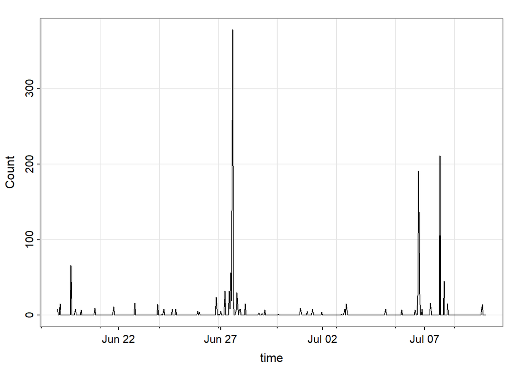

```r
# take a subset for analysis
# and split into training and testing set.

nbf_hour_ts_total_1 <- ts(nbf_hour_complete$number_of_objects[(5):(5+504+12)], frequency = 24)
nbf_hour_ts_train_1 <- ts(nbf_hour_complete$number_of_objects[(5):(5+504)], frequency = 24)
nbf_hour_ts_test_1 <-
  ts(nbf_hour_complete$number_of_objects[(510):(510+12)], frequency = 24, start = c(22, 1))


time_nbf_hour_ts_train <- strptime(nbf_hour_complete$time[(5):(504+5)], "%m/%d/%Y %H:%M")
tsplot(x=time_nbf_hour_ts_train, y=nbf_hour_ts_train_1, xlab = 'time', ylab = 'Count')
```

First, I plot the original data to confirm non-stationarity, where stationarity is defined as follows:

$Y_t$ is strictly stationary if $\forall k, m, t_1, ..., t_m$: $(Y_{t_1}, Y_{t_2}, . . . , Y_{t_m}) d= (Y_{t_1+k}, Y_{t_2+k}, . . . , Y_{t_m+k})$.

$Y_t$ is weakly stationary if $\forall k, s, t$: $E(Y_s) = E(Y_t)$ (no trend) and $cov(Y_t, Y_{t+k}) = cov(Y_s , Y_{s+k})$ (Constant covariance).

```r
# apply Box-Cox transformation to make the variance constant
bc_nbf_hour_ts_total_1<-boxcox(lm((nbf_hour_ts_total_1+0.5) ~ 1))
```

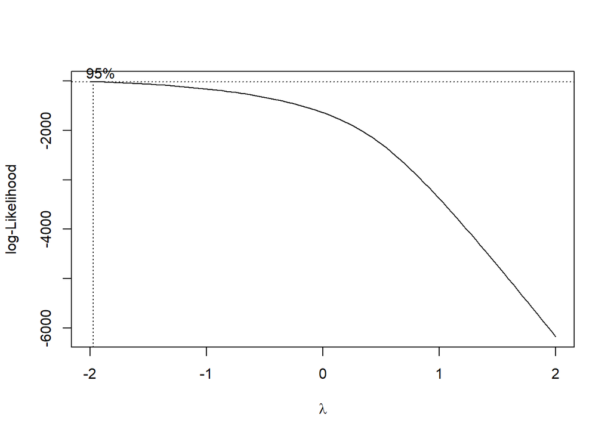

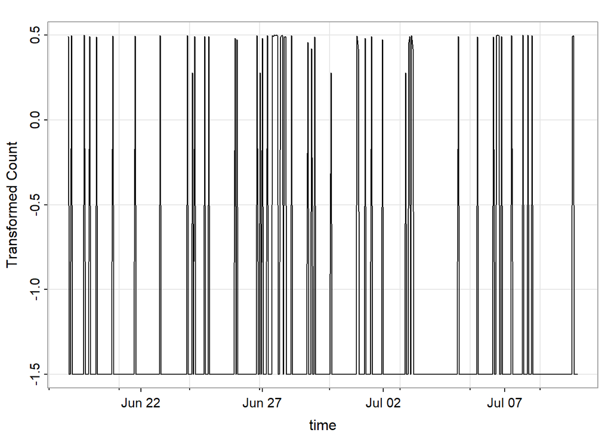

```r
lambda_bc_nbf_hour_ts <- bc_nbf_hour_ts_total_1$x[which.max(bc_nbf_hour_ts_total_1$y)]
nbf_hour_ts_train <- BoxCox(nbf_hour_ts_train_1+0.5, lambda_bc_nbf_hour_ts)
nbf_hour_ts_test <- BoxCox(nbf_hour_ts_test_1+0.5, lambda_bc_nbf_hour_ts)
nbf_hour_ts_total <- BoxCox(nbf_hour_ts_total_1+0.5, lambda_bc_nbf_hour_ts)

tsplot(x=time_nbf_hour_ts_train,y=nbf_hour_ts_train, xlab = 'time', ylab = 'Transformed Count')
```

Mathematically, the Box-Cox transformation of the variable has the form:

$y(\lambda) = \frac{y^{\lambda} - 1}{\lambda}$ if $\lambda \neq 0$

$y(\lambda) = log(y)$ if $\lambda = 0$.

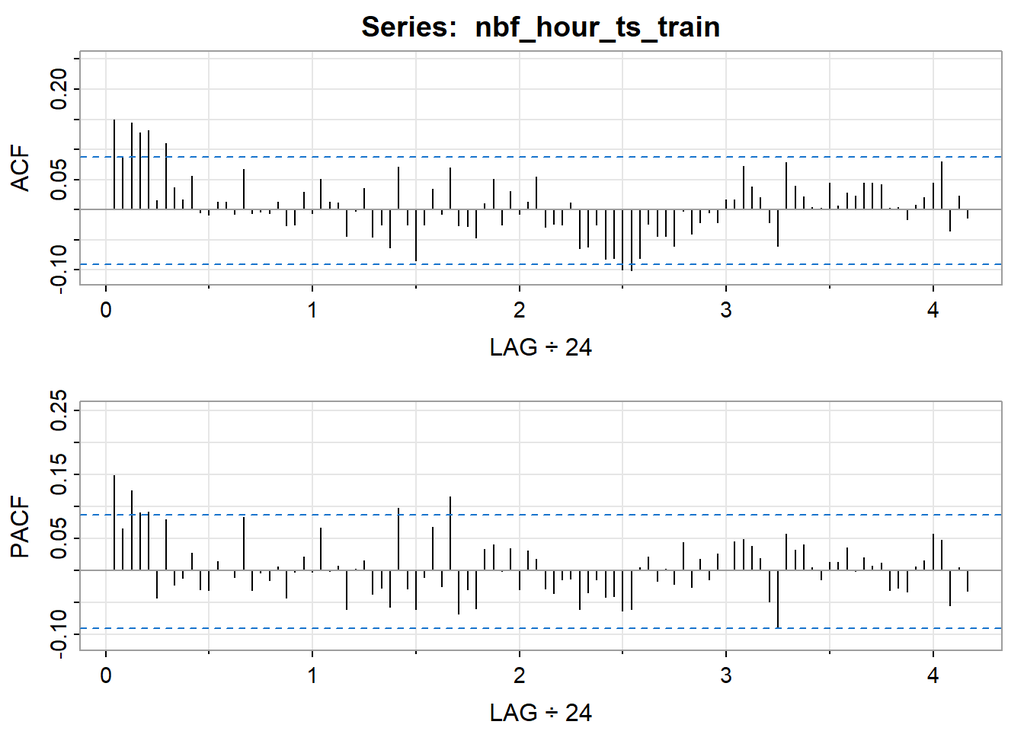

```
##      [,1] [,2] [,3] [,4] [,5]  [,6] [,7]  [,8]  [,9] [,10] [,11] [,12] [,13]
## ACF  0.15 0.09 0.14 0.13 0.13  0.01 0.11  0.04  0.02  0.06  0.00 -0.01  0.01
## PACF 0.15 0.07 0.13 0.09 0.09 -0.04 0.08 -0.02 -0.01  0.03 -0.03 -0.03  0.01
##      [,14] [,15] [,16] [,17] [,18] [,19] [,20] [,21] [,22] [,23] [,24] [,25]
## ACF   0.01 -0.01  0.07 -0.01     0 -0.01  0.01 -0.03 -0.03  0.03 -0.01  0.05
## PACF  0.00 -0.01  0.08 -0.03     0 -0.02  0.01 -0.04  0.00  0.02  0.00  0.07
##      [,26] [,27] [,28] [,29] [,30] [,31] [,32] [,33] [,34] [,35] [,36] [,37]
## ACF   0.01  0.01 -0.04     0  0.04 -0.05 -0.03 -0.06  0.07 -0.02 -0.08 -0.03
## PACF  0.00  0.01 -0.06     0  0.02 -0.04 -0.03 -0.06  0.10 -0.03 -0.06 -0.01
##      [,38] [,39] [,40] [,41] [,42] [,43] [,44] [,45] [,46] [,47] [,48] [,49]
## ACF   0.03 -0.01  0.07 -0.03 -0.03 -0.05  0.01  0.05 -0.03  0.03 -0.01  0.01
## PACF  0.07 -0.03  0.12 -0.07 -0.03 -0.06  0.03  0.04  0.00  0.03 -0.03  0.03
##      [,50] [,51] [,52] [,53] [,54] [,55] [,56] [,57] [,58] [,59] [,60] [,61]
## ACF   0.05 -0.03 -0.02 -0.03  0.01 -0.06 -0.06 -0.02 -0.08 -0.08 -0.10 -0.10
## PACF  0.02 -0.03 -0.04 -0.01 -0.01 -0.06 -0.03 -0.01 -0.04 -0.04 -0.06 -0.06
##      [,62] [,63] [,64] [,65] [,66] [,67] [,68] [,69] [,70] [,71] [,72] [,73]
## ACF  -0.08 -0.02 -0.04 -0.04 -0.06  0.00 -0.04 -0.02  0.00 -0.02  0.02  0.02
## PACF  0.01  0.02 -0.02  0.00 -0.02  0.04 -0.03  0.02 -0.01  0.03  0.00  0.05
##      [,74] [,75] [,76] [,77] [,78] [,79] [,80] [,81] [,82] [,83] [,84] [,85]
## ACF   0.07  0.04  0.02 -0.02 -0.06  0.08  0.04  0.02     0  0.00  0.04  0.01
## PACF  0.05  0.04  0.02 -0.05 -0.09  0.06  0.03  0.04     0 -0.01  0.01  0.01
##      [,86] [,87] [,88] [,89] [,90] [,91] [,92] [,93] [,94] [,95] [,96] [,97]
## ACF   0.03  0.02  0.04  0.04  0.04  0.00  0.00 -0.02  0.01  0.02  0.04  0.08
## PACF  0.04  0.00  0.02  0.01  0.01 -0.03 -0.03 -0.03  0.01  0.02  0.06  0.05
##      [,98] [,99] [,100]
## ACF  -0.04  0.02  -0.01
## PACF -0.06  0.00  -0.03
```

```r
acf2(nbf_hour_ts_train, max.lag = 100)
```

```r
adf.test(nbf_hour_ts_train)
```

```
##
##  Augmented Dickey-Fuller Test
##
## data:  nbf_hour_ts_train
## Dickey-Fuller = -6.0935, Lag order = 7, p-value = 0.01
## alternative hypothesis: stationary
```

```r
Box.test(nbf_hour_ts_train, lag = 24, type = c("Ljung-Box"), fitdf = 0)
```

```
##
##  Box-Ljung test
##
## data:  nbf_hour_ts_train
## X-squared = 55.639, df = 24, p-value = 0.0002566
```

ACF plot and PACF plot do not show slow decay of spikes or significant spikes periodically, meaning that after transformation, the time series does not have trend or seasonal component so that it is stationary.

To further confirm that the time series is stationary, I perform the ADF test. To ensure that the stationary time series is not a white noise so that the modelling is meaningful, I perform the Ljung–Box test.

ADF test:

Null Hypothesis: Series is non-stationary or series has a unit root.

Alternate Hypothesis: Series is stationary or series has no unit root.

Null Hypothesis: The data are independently distributed.

Alternate Hypothesis:The data are not independently distributed; they exhibit serial correlation.

The p-value of both tests are less than 0.05, and thus we can reject the null hypothesis and take that the series is not a white noise and stationary.

### North Beach Fort Cam - Model identification

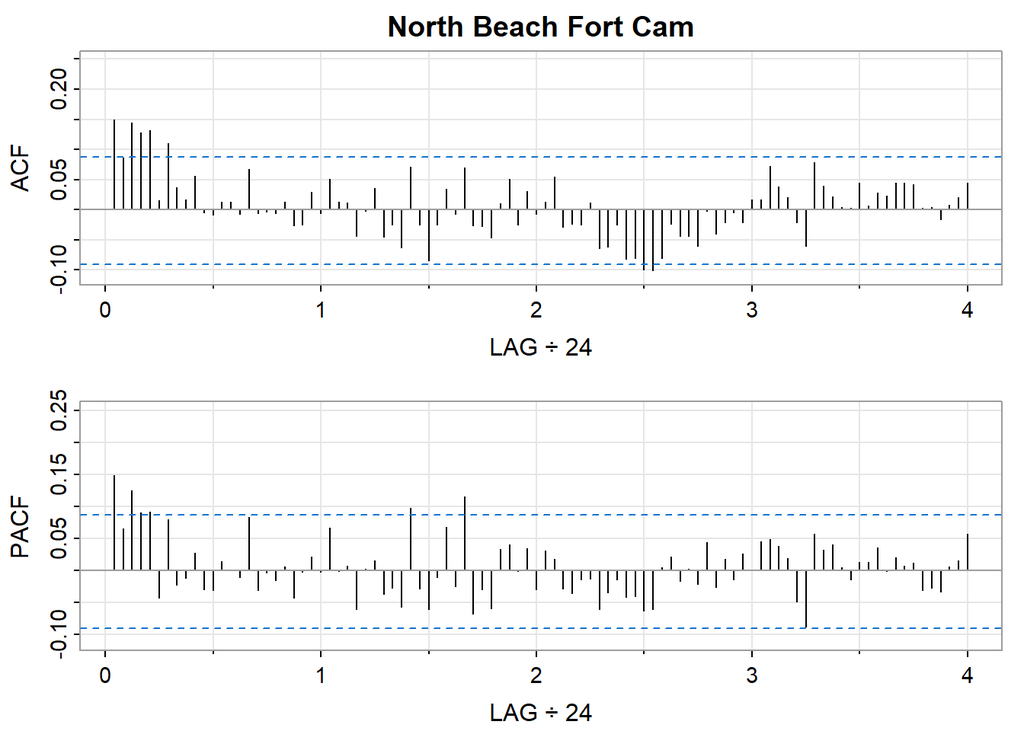

```
##      [,1] [,2] [,3] [,4] [,5]  [,6] [,7]  [,8]  [,9] [,10] [,11] [,12] [,13]
## ACF  0.15 0.09 0.14 0.13 0.13  0.01 0.11  0.04  0.02  0.06  0.00 -0.01  0.01
## PACF 0.15 0.07 0.13 0.09 0.09 -0.04 0.08 -0.02 -0.01  0.03 -0.03 -0.03  0.01
##      [,14] [,15] [,16] [,17] [,18] [,19] [,20] [,21] [,22] [,23] [,24] [,25]
## ACF   0.01 -0.01  0.07 -0.01     0 -0.01  0.01 -0.03 -0.03  0.03 -0.01  0.05
## PACF  0.00 -0.01  0.08 -0.03     0 -0.02  0.01 -0.04  0.00  0.02  0.00  0.07
##      [,26] [,27] [,28] [,29] [,30] [,31] [,32] [,33] [,34] [,35] [,36] [,37]
## ACF   0.01  0.01 -0.04     0  0.04 -0.05 -0.03 -0.06  0.07 -0.02 -0.08 -0.03
## PACF  0.00  0.01 -0.06     0  0.02 -0.04 -0.03 -0.06  0.10 -0.03 -0.06 -0.01
##      [,38] [,39] [,40] [,41] [,42] [,43] [,44] [,45] [,46] [,47] [,48] [,49]
## ACF   0.03 -0.01  0.07 -0.03 -0.03 -0.05  0.01  0.05 -0.03  0.03 -0.01  0.01
## PACF  0.07 -0.03  0.12 -0.07 -0.03 -0.06  0.03  0.04  0.00  0.03 -0.03  0.03
##      [,50] [,51] [,52] [,53] [,54] [,55] [,56] [,57] [,58] [,59] [,60] [,61]
## ACF   0.05 -0.03 -0.02 -0.03  0.01 -0.06 -0.06 -0.02 -0.08 -0.08 -0.10 -0.10
## PACF  0.02 -0.03 -0.04 -0.01 -0.01 -0.06 -0.03 -0.01 -0.04 -0.04 -0.06 -0.06
##      [,62] [,63] [,64] [,65] [,66] [,67] [,68] [,69] [,70] [,71] [,72] [,73]
## ACF  -0.08 -0.02 -0.04 -0.04 -0.06  0.00 -0.04 -0.02  0.00 -0.02  0.02  0.02
## PACF  0.01  0.02 -0.02  0.00 -0.02  0.04 -0.03  0.02 -0.01  0.03  0.00  0.05
##      [,74] [,75] [,76] [,77] [,78] [,79] [,80] [,81] [,82] [,83] [,84] [,85]
## ACF   0.07  0.04  0.02 -0.02 -0.06  0.08  0.04  0.02     0  0.00  0.04  0.01
## PACF  0.05  0.04  0.02 -0.05 -0.09  0.06  0.03  0.04     0 -0.01  0.01  0.01
##      [,86] [,87] [,88] [,89] [,90] [,91] [,92] [,93] [,94] [,95] [,96]
## ACF   0.03  0.02  0.04  0.04  0.04  0.00  0.00 -0.02  0.01  0.02  0.04
## PACF  0.04  0.00  0.02  0.01  0.01 -0.03 -0.03 -0.03  0.01  0.02  0.06
```

```r
acf2(nbf_hour_ts_train, main = "North Beach Fort Cam" )
```

ACF shows a geometric decay over the non-seasonal lags, which could be a sign of autoregression.

PACF also shows a geometric decay over the non-seasonal lags, which could be a sign of Moving average.

Since it is a ARMA process , the exact values of p and q cannot be determined with the ACF/PACF plots.

White noise: $Z_t$ are mean zero, constant variance and uncorrelated: $\mu_Z(t) = E(Z_t) = 0$, $\gamma_Z(t,s) = cov(Z_t, Z_s) = 0$ if $t \neq s$; $\gamma_Z(t,t) = cov(Z_t, Z_t) = \sigma_Z^2$.

Autoregression AR(p) process: Let $\{\epsilon_t\}\mathtt{\sim}WN(0,\sigma^2)$, then $Yt$ is an autoregressive process of order p, AR(p), if $Y_t = \phi_1Y_{t-1} + \phi_2Y_{t-2} + ... + \phi_pY_{t-p} + \epsilon_{t}$.

Equivalently, $Y_t(1 - \phi_1B - \phi_2B^2 - ... - \phi_pB^p) = Y_t\phi(B) = \epsilon_{t}$, with characteristic polynomial $\phi(z) = (1 - \phi_1B - \phi_2B^2 - ... - \phi_pB^p)$, where $B$ denotes the backshift operator, $B^nY_t = Y_{t-n}$.

Moving average MA(q) process: Let $\{\epsilon_t\}\mathtt{\sim}WN(0,\sigma^2)$, then $Y_t$ is a moving average process of order q, MA(q), if $Y_t = \epsilon_t + \theta_1\epsilon_{t-1} + \theta_2\epsilon_{t-2} + ...+\theta_q\epsilon_{t-q}$.

Equivalently, $\epsilon_{t}(1 + \theta_1B + \theta_2B^2 + ... + \theta_qB^q) = \epsilon_{t}\theta(B) = Y_t$, with characteristic polynomial $\theta(z) = (1 + \theta_1B + \theta_2B^2 + ... + \theta_qB^q)$.

### North Beach Fort Cam - Modelling

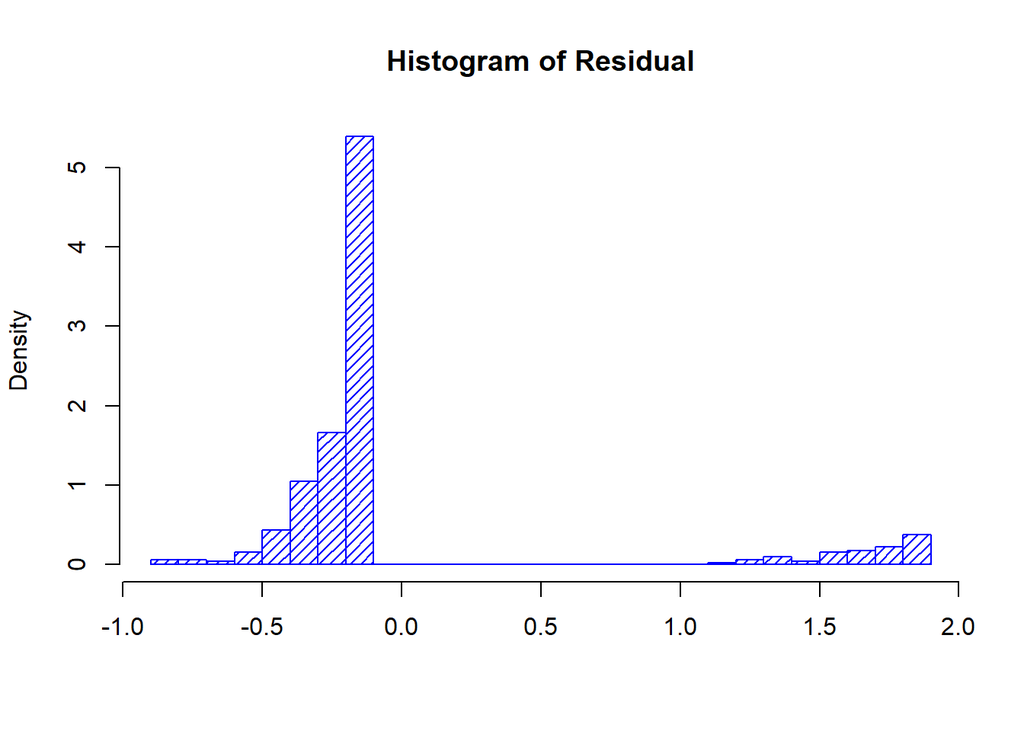

```r
# auto.arima(nbf_hour_ts_train, max.order = 2, trace=TRUE) ## Best model: ARIMA(1,0,1)(1,0,0)[24]
nbf_hour_model_auto <-arima(nbf_hour_ts_train, order=c(1,0,1),seasonal = list(order=c(1,0,0),period=24))

#### Model diagnosis - auto.arima ####
# 1. Normality test
residual_nbf_hour_model_auto <- residuals(nbf_hour_model_auto)
hist(residual_nbf_hour_model_auto,density=20,breaks=20,col="blue",xlab="",main = "Histogram of Residual",prob=TRUE)
```

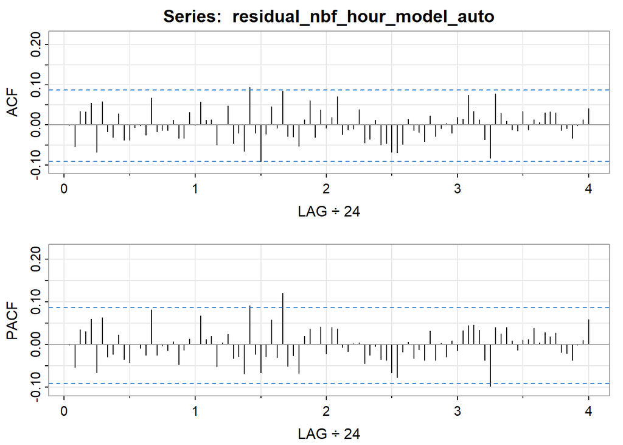

```
##      [,1]  [,2] [,3] [,4] [,5]  [,6] [,7]  [,8]  [,9] [,10] [,11] [,12] [,13]
## ACF     0 -0.05 0.03 0.03 0.06 -0.07 0.06 -0.02 -0.03  0.03 -0.04 -0.04 -0.01
## PACF    0 -0.05 0.03 0.03 0.06 -0.07 0.06 -0.03 -0.02  0.02 -0.03 -0.04  0.00
##      [,14] [,15] [,16] [,17] [,18] [,19] [,20] [,21] [,22] [,23] [,24] [,25]
## ACF   0.00 -0.03  0.07 -0.02 -0.01 -0.01  0.01 -0.03 -0.03  0.03     0  0.06
## PACF -0.01 -0.02  0.08 -0.03  0.00 -0.01  0.01 -0.05 -0.01  0.01     0  0.07
##      [,26] [,27] [,28] [,29] [,30] [,31] [,32] [,33] [,34] [,35] [,36] [,37]
## ACF   0.01  0.01 -0.05     0  0.05 -0.05 -0.02 -0.06  0.09 -0.02 -0.09 -0.02
## PACF  0.01  0.02 -0.05     0  0.02 -0.03 -0.03 -0.07  0.09 -0.02 -0.07 -0.03
##      [,38] [,39] [,40] [,41] [,42] [,43] [,44] [,45] [,46] [,47] [,48] [,49]
## ACF   0.05 -0.01  0.09 -0.03 -0.03 -0.05  0.01  0.06 -0.03  0.04 -0.01  0.02
## PACF  0.06 -0.03  0.12 -0.05 -0.03 -0.07  0.02  0.04  0.00  0.04 -0.02  0.04
##      [,50] [,51] [,52] [,53] [,54] [,55] [,56] [,57] [,58] [,59] [,60] [,61]
## ACF   0.07 -0.02 -0.01 -0.01  0.04 -0.04 -0.04  0.01 -0.05 -0.05 -0.07 -0.07
## PACF  0.04 -0.01 -0.02  0.00  0.00 -0.04 -0.03  0.00 -0.03 -0.04 -0.07 -0.08
##      [,62] [,63] [,64] [,65] [,66] [,67] [,68] [,69] [,70] [,71] [,72] [,73]
## ACF  -0.05  0.01 -0.01 -0.02 -0.04  0.02 -0.03 -0.01  0.00 -0.02  0.02  0.01
## PACF -0.02  0.00 -0.03 -0.01 -0.04  0.03 -0.04  0.00 -0.03  0.01 -0.01  0.03
##      [,74] [,75] [,76] [,77] [,78] [,79] [,80] [,81] [,82] [,83] [,84] [,85]
## ACF   0.07  0.03  0.01 -0.04 -0.08  0.08  0.03  0.01 -0.01 -0.01  0.03 -0.01
## PACF  0.04  0.05  0.03 -0.04 -0.10  0.04  0.02  0.04  0.01 -0.01  0.01  0.01
##      [,86] [,87] [,88] [,89] [,90] [,91] [,92] [,93] [,94] [,95] [,96]
## ACF   0.01  0.01  0.03  0.03  0.03 -0.01 -0.01 -0.03     0  0.01  0.04
## PACF  0.04  0.00  0.03  0.02  0.03 -0.02 -0.02 -0.04     0  0.01  0.06
```

```r
# 2. Correlation test
acf2(residual_nbf_hour_model_auto)
```

```r
# ACF plot / PACF plot show almost no significant spike.

Box.test(residual_nbf_hour_model_auto, type = c("Box-Pierce"))
```

```
##
##  Box-Pierce test
##
## data:  residual_nbf_hour_model_auto
## X-squared = 0.00035981, df = 1, p-value = 0.9849
```

```r
Box.test(residual_nbf_hour_model_auto, lag = 24, type = c("Box-Pierce"))
```

```
##
##  Box-Pierce test
##
## data:  residual_nbf_hour_model_auto
## X-squared = 15.168, df = 24, p-value = 0.9157
```